# Predict Quality of Barbell Lifting Exercise

### Synopsis

As part of self quantification, we have to create a machine learning model that can predict the quality of an individual’s barbell lifting exercise. The dataset (both training and testing) used for this exercise was captured using self tracking device. The dataset consisted of 19622 observations and 160 variables. Utilizing correlation and the fact that this modeling is to quantify the quality of barbell lifting, I picked the following variables to be included in the training and testing datasets.

```r
"gyros_dumbbell_x","gyros_dumbbell_y", "gyros_dumbbell_z", "accel_dumbbell_x", "accel_dumbbell_y", "accel_dumbbell_z",
           "magnet_dumbbell_x", "magnet_dumbbell_y", "magnet_dumbbell_z", "gyros_forearm_x", "gyros_forearm_y", "gyros_forearm_z",
           "accel_forearm_x", "accel_forearm_y", "accel_forearm_z", "magnet_forearm_x", "magnet_forearm_y", "magnet_forearm_z"
```

Given the multi-level outcomes of this dataset, I decided to create a Random Forest model to predict the outcome.

### Model Creation

As part of the training, I’ll split the given training dataset into two - training dataset and validation dataset. This is for cross validation and to identify out-of-bag/ in-bag error. I want to find out how accurate our trained model is.

#### Preliminary Preparation

```r
## read data
training = read.csv("pml-training.csv")
testing = read.csv("pml-testing.csv")

cNames = c("gyros_dumbbell_x","gyros_dumbbell_y", "gyros_dumbbell_z", "accel_dumbbell_x", "accel_dumbbell_y", "accel_dumbbell_z",
           "magnet_dumbbell_x", "magnet_dumbbell_y", "magnet_dumbbell_z", "gyros_forearm_x", "gyros_forearm_y", "gyros_forearm_z",
           "accel_forearm_x", "accel_forearm_y", "accel_forearm_z", "magnet_forearm_x", "magnet_forearm_y", "magnet_forearm_z")

dfTrain = training[,cNames]
dfTrain = cbind(dfTrain, training$classe)
colnames(dfTrain)[19] = "classe"
dfTest  = testing[,cNames]

## Split the training into two for cross validation and out-of-bag/ in-bag error. In other words, I want to find out the
## accuracy of our trained model
inTrain = createDataPartition(y=dfTrain$classe, p=0.75, list=FALSE)
dfT = dfTrain[inTrain,]
dfV = dfTrain[-inTrain,]
```

#### Data Exploration

Before we dig further, let’s explore the training dataset

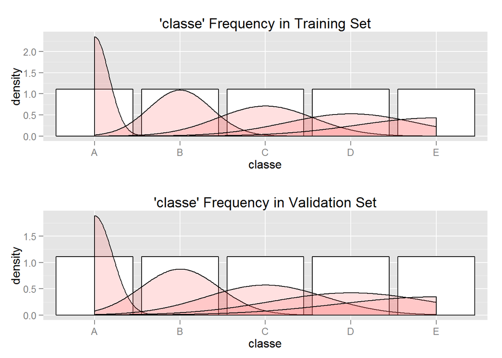

```r
## Exploration
#~~~ frequency
p1 = ggplot(dfT, aes(x=classe)) + geom_histogram(aes(y=..density..),binwidth=.2, colour="black", fill="white") +
  ggtitle("'classe' Frequency in Training Set") +
  geom_density(alpha=.2, fill="#FF6666")

p2 = ggplot(dfV, aes(x=classe)) + geom_histogram(aes(y=..density..), binwidth=.2, colour="black", fill="white") +
  ggtitle("'classe' Frequency in Validation Set")+
  geom_density(alpha=.2, fill="#FF6666")

grid.arrange(p1, p2)
```

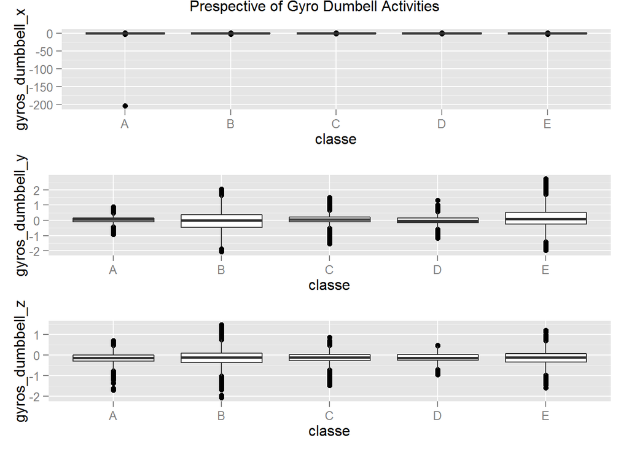

```r
#~~~ boxplot
b1 = ggplot(dfT, aes(x=classe, y=gyros_dumbbell_x)) + geom_boxplot()
b2 = ggplot(dfV, aes(x=classe, y=gyros_dumbbell_y)) + geom_boxplot()
b3 = ggplot(dfV, aes(x=classe, y=gyros_dumbbell_z)) + geom_boxplot()

grid.arrange(b1, b2, b3, main = "Prespective of Gyro Dumbell Activities") # notice the outliers; hoping PCA processing should smooth that out.
```